# Machine Learning Coursework (Part 1)

Since I cannot convert the provided html file into ipynb file successfully, then I have to create my own new file and copy some certain words ,such as the sectioin title, to here. Therefore,this file may be a little bit different from the provided file, which may lost a lof of description and hint.

## 1. Explaoratory Data Analysis

```python
# set matplotlib backend to inline
%matplotlib inline

# import modules
from sklearn import datasets
import numpy as np
import matplotlib.pyplot as plt
import pandas as pd

# load data
wine=datasets.load_wine()
#print(wine.DESCR)

# this dataset has 13 features, we will only choose a subset of these
df_wine = pd.DataFrame(wine.data, columns = wine.feature_names )
selected_features = ['alcohol','flavanoids','color_intensity','ash']

# extract the data as numpy arrays of features, X, and target, y
X = df_wine[selected_features].values
y = wine.target
```

### 1.1. Visualising the data

```python
"""#####
I used these codes to check the data so that I can understand better, but here I can not run it.Since the dataset was used before,
If I run the code then the dataset will come out and this will be dectected as copy,which will cause a high plagiarism on me
   #####
df_wine.shape()
df_wine.duplicated().any() #check any repeated value
df_wine.describe() #show data details

"""
```

```
'#####\nI used these codes to check the data so that I can understand better, but here I can not run it.Since the dataset was used before,\nIf I run the code then the dataset will come out and this will be dectected as copy,which will cause a high plagiarism on me\n   #####\ndf_wine.shape()\ndf_wine…
```

```python
# define plotting function
"""
    This function creates a 4x4 grid of subplots to visualize the interactions between the features in the input data.
    Parameters:
    - X : 2D array of feature data
    - y : 1D array of class labels corresponding to the data in X
    Returns:
    - None
"""
def myplotGrid(X,y):
    # Initialize the figure and axes
    fig, axes = plt.subplots(4, 4, figsize=(12, 12))
    fig.suptitle("Features Interaction Visualization")

    # Create a list of arrays for each class
    dataPerClass = [np.array([X[n] for n in range(0, len(X)) if y[n] == i]) for i in range(3)]

    # Loop over the subplots
    for i in range(4):
        for k in range(4):
            ax = axes[i][k]

            # Plot histograms for diagonal subplots
            if i == k:
                for d in dataPerClass:
                    ax.hist(d[:, i])
            # Plot scatter plots for non-diagonal subplots
            else:
                for l, d in enumerate(dataPerClass):
                    ax.scatter(d[:, i], d[:, k], label=wine.target_names[l])

            # Add legend in top right corner
            if i == 3 and k == 0:
                ax.legend()

            # Add x-label for bottom row of subplots
            if k == 3:
                ax.set_xlabel(wine.feature_names[i])

            # Add y-label for leftmost column of subplots
            if i == 0:
                ax.set_ylabel(wine.feature_names[k])
```

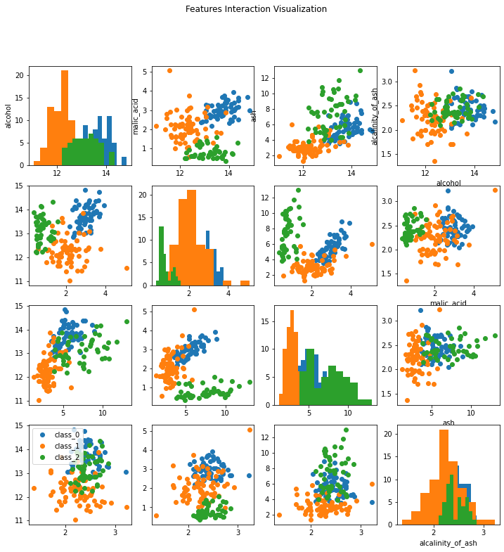

```python
# run the plotting function
myplotGrid(X,y)
```

### 1.2. Exploratory Data Analysis under noise

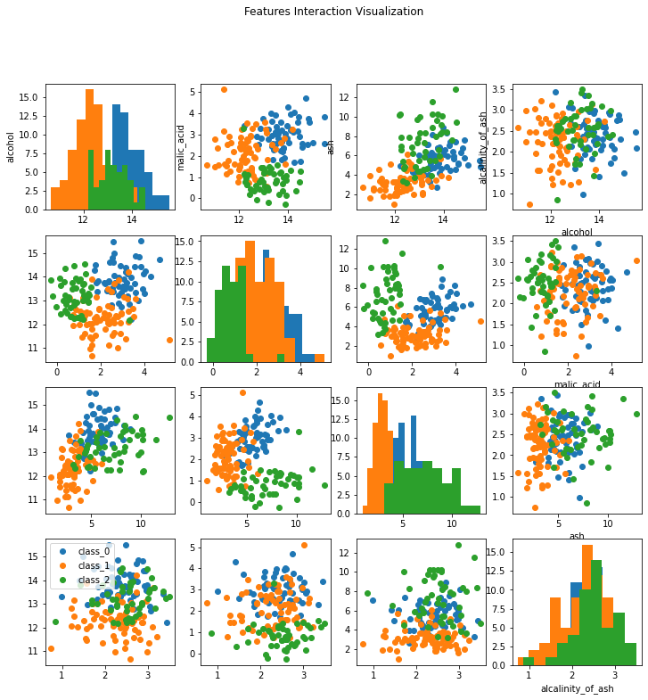

```python
# noise code
mySeed = 1234567
np.random.seed(mySeed)
XN=X+np.random.normal(0,0.5,X.shape)
myplotGrid(XN, y)
```

### Q1. Exploratory data analysis

Based on your exploratory analysis, if you were to build a classifier using only two of the available features, which ones would you choose and why? Answer as fully as you can.

### Q2. Data with noise

What do you observe by plotting the data without noise compared to plotting with added Gaussian noise?

#### Answer:

While the graphs with and without noise may be distinguished from one another more clearly, the graphs with noise exhibit greater crossover.

## 2. Implementing kNN

```python
# helper code
import math
import random
import numpy as np
from collections import Counter
from sklearn.model_selection import train_test_split


#Function to calculate the distance
#Euclidean Distance
#2d vectors distance is calculated, distance is returned
'''Calculate the euclidean distance of two n-dimensional vectors
        ----------
        Takes:
            - a
            - b
        Returns:
            - distance
        ----------
'''
def euclidean_dist(a,b):
    return np.linalg.norm(a-b,axis=0)

#Manhattan Distance
''' Calculate the manhattan distance of two n-dimensional vectors
        ----------
        Takes:
            - j,initial j value
            - k,initial k value
        Returns:
            - distance,result of distance calculated by Manhattan
        ----------
'''

def manhattan_dist(j, k):
        # Assert that the length of arrays j and k are the same
    assert len(j) == len(k), "Arrays j and k must have the same length"
    dist = 0
    for i in range(len(j)):
        dist += abs(j[i] - k[i])
    return dist

#Train the splitData
''' Splits inputs and outputs in ratio given by fraction
        ----------
        Takes:
            - X, Initial X value
            - y, Initial y value
            - ts = test size:0-1
        Returns
            - X_train, means trained value from X
            - X_test, means tested value from y
            - y_train, means trained value from y
            - y_test,means tested value from y
        ----------
'''
def splitData(X, y, ts):
    # Assert that the test size is between 0 and 1
    assert (ts > 0.0 and ts < 1.0), "Please insert a test size between 0 and 1"
    # Use the train_test_split function to split the data into train and test sets
    X_train, X_test, y_train, y_test = train_test_split(X, y, test_size=ts, random_state=mySeed)
    return (X_train, X_test, y_train, y_test)

''' Calculate overall accuracy
        ----------
            Takes:
                - a list contians result of test values
                - a list contains result of predicted values
            Returns:
                - result of accuracy value
        ----------
'''
def Accuracy(y_test, y_pred):
    return np.mean(y_test == y_pred)
```

```python
# mykNN code
'''Returns predicted values when given training data and labels, a test set, k neighbours and distance type.
        -----------
        Takes:
           - X=training inputs value,
           - y=training outputs value,
           - X=test inputs value,
           - k=number of neighbours,
           - distance_type= "euclidian" or "manhattan"
        Returns:
           - List contains result of predicted values for those test inputs.
        -----------
'''
def mykNN(X_train, y_train, X_test, k, distance_type):
    predicted=[]
# Every test sample's fit and prediction
    for x in X_test:
        neighbours=[[],[]]
    # Get the euclidian or manhattan distances between all of the training samples and the test sample.
        if distance_type=="euclidean":
            distances = [euclidean_dist(x, j) for j in X_train]
        elif distance_type=="manhattan":
            distances = [manhattan_dist(x, j) for j in X_train]
    # Get indices of the k smallest distances
        k_nearest_ids = np.argsort(distances)[:k]
    # Collect the k nearest neighbors' labels.
        k_nearest_labels = [y_train[m] for m in k_nearest_ids]
        counts = np.bincount(k_nearest_labels)
    # Among the k closest neighbors, predicted class is the most prevalent class.
        predicted.append(np.argmax(counts))
    return np.array(predicted)

# Split
X_train, X_test, y_train, y_test = splitData(X, y, 0.5)
# Get predicted values
y_ = mykNN(X_train, y_train, X_test,5, "euclidean")

print("Predicted values: \n")
print(y_)
print("\n")
print("True values: \n")
print(y_test)
print("\n")
print(Accuracy(y_test, y_))
```

```
Predicted values:

[2 0 0 0 1 0 0 1 1 0 2 1 2 1 0 1 2 0 2 2 1 0 1 0 2 0 0 0 0 1 1 1 2 0 2 0 2
 0 0 0 0 0 2 0 0 2 2 0 1 0 2 0 1 1 0 2 1 0 1 0 1 0 2 1 1 1 0 1 0 1 1 1 2 2
 0 1 1 2 0 1 1 0 0 2 2 1 0 0 0]


True values:

[2 0 0 1 1 0 0 1 1 0 2 1 2 1 0 1 2 0 2 2 1 1 1 0 2 0 0 0 0 1 1 1 2 0 2 1 2
 0 0 0 0 0 2 0 0 2 1 0 1 0 2 0 1 1 0 2 1 0 1 0 1 0 2 1 1 1 1 1 0 1 1 2 2 2
 0 1 1 2 0 1 1 0 0 2 2 1 0 0 0]


0.9325842696629213
```

## 3. Classifier evaluation

```python
# confusion matrix, accuracy, precision, recall, etc.
#the method should return the confusion matrix in a numpy array
''' Returns a confusion matrix of predicted and ground truth values.
        ----------
        Takes:
            - Array of test data labels,y_test
            - Array of predicted values,y_pred
            - Number of classes
        Returns:
            - nxn Confusion matrix
        ----------
'''
def Confusion_Matrix(y_test,y_pred,nClasses):
    # Initialise an n dimensional matrix of zeros
    e = np.zeros((nClasses,nClasses),dtype=np.int64)
    # Loop over predicted values updating matrix appropriately
    for i in range(0, len(y_pred)):
        e[y_test[i]][y_pred[i]] +=1
    #loop through all results and update the confusion matrix
    return e

''' Gets class by class precision
        ----------
        Takes:
            - Test outputs,y_test
            - Predicted values,y_pred
        Returns:
            - List with precision for each class
        ----------
'''
def Precision(y_test,y_pred):
    # Get array of classes
    classes = np.unique(y_test)
    # Get number of classes
    n = len(classes)
    # Initialise array of zeros for class by class results
    precision = np.zeros(classes.shape)
    # get confusion matrix
    cm = Confusion_Matrix(y_test, y_pred, n)
    # loop over results and classes
    for i in range(0, n):
        # Initialise true positive + false positive variable
        sum_of_tpfp = 0
        for j in classes:
            # true positives + false positives
            sum_of_tpfp += cm[j][i]
        # precision = true positives / true positives + false positives
        class_precision = cm[i][i] / sum_of_tpfp
        precision[i] = class_precision
    return precision

''' Gets class by class Recall
        ----------
        Takes:
            - Test outputs,y_test
            - Predicted values,y_pred
        Returns:
            - List contains of with recall for each class
        ----------
'''
def Recall(y_test,y_pred):
       # Get array of classes
    classes = np.unique(y_pred)
    # Get number of classes
    n = len(classes)
    # Initialise array of zeros for class by class results
    recall = np.zeros(classes.shape)
    # Get confusion matrix
    cm = Confusion_Matrix(y_test, y_pred, n)
    # Loop over the classes
    for m in classes:
        # Recall = true positives / (true positives + false negatives)
        recall[m] = cm[m][m] / sum(cm[m])
    return recall

#use the numpy function where to return the accuracy given the true/predicted labels.
'''Calculates overall accuracy
        ----------
            Takes:
                - list of test values,y_test
                - list of predicted values,y_pred
            Returns:
                - Accuracy value
        ----------
    '''
def Accuracy(y_test,y_pred):
    accuracy = len(y_test[np.where(y_test==y_pred)])/len(y_pred) #np.where()
    return accuracy
```

```python
# test evaluation code
print("homemade functions:")
print("value of accuracy: %0.3f" % Accuracy(y_test,y_))
print('classes:      %s ' % np.unique(y_) )
print('value of precision: %s' % Precision(y_test,y_))
print('value of recall:    %s \n\n' % Recall(y_test,y_))
```

```
homemade functions:
value of accuracy: 0.933
classes:      [0 1 2]
value of precision: [0.8974359  0.96551724 0.95238095]
value of recall:    [1.         0.84848485 0.95238095]
```

## 4. Nested Cross-validation using your implementation of KNN

```python
# NestedCrossVal code
""" Nest Cross Validation of Knn.
        ----------
        Takes:
            - inputs,
            - outputs,
            - number of folds,
            - list: range of neighbour values,
            - list of distance names: "euclidean","manhattan"
            - random seed.
        Returns:
            - list of accuracies,
            - list of parameters,
            - list of confusion matrices
        ----------
    """
def Nested_CrossVal(X,y,foldk,nns,dists,mySeed):
    #conf_matrices, accuracy_fold, parameters_fold are initialised
    np.random.seed(mySeed)
    conf_matrices=[]
    accuracy_fold=[]
    parameters_fold=[]
    #TASK: use the function np.random.permutation to generate a list of shuffled indices from in the range (0,number of data)

    #list of shuffled indices are generated
    indices = np.random.permutation(list(range(X.shape[0])))

    #TASK: use the function array_split to split the indices to foldK different bins
    #for splitting the indices to different bins array_split is used
    bins=np.array_split(indices, foldk)

    #proving foldK and bin num length values are equal
    assert(foldk==len(bins))
    #foldK is looped
    for i in range(foldk):
# indices for testing
        foldTest = bins[i]
# indices for validation
        foldVal = bins[(i+1)%foldk]
# indices for training
        foldTrain = [index for j, bin in enumerate(bins) if j not in [i, (i+1)%foldk] for index in bin]

        #save the best attained accuracy here (in terms of validation)
        bestAccuracy=-10
        #save the best number of neighbours here
        bestNumNeighbours=-1
        #save the best distance metric here
        bestDistance=''

        # loop through all parameters (one for loop for distances, one for loop for nn)
        # train the classifier on current number of neighbours/distance
        # obtain results on validation set
        #save parameters if results are the best we had
        for d in dists:
            #nns is looped
            for nn in nns:
                #knn classifier is defined
                y_pred=mykNN(X[foldTrain],y[foldTrain],X[foldVal],nn,d)
                #accuracy value is generated
                accuracy = Accuracy(y[foldVal], y_pred)
                #the accuracy values are compared
                if accuracy > bestAccuracy:
                    bestAccuracy = accuracy
                    bestNumNeighbours = nn
                    bestDistance = d

        #by including the validation values the training data set in extended
        foldTrain.extend(foldVal)

        #passing kNN on fold values
        y_=mykNN(X[foldTrain],y[foldTrain],X[foldTest],bestNumNeighbours,bestDistance)

        #Accuracy measurement using fold values
        accuracy_=Accuracy(y[foldTest],y_)
        #using .append() values are added into accuracy_value
        accuracy_fold.append(accuracy)
        parameters_fold.append((bestDistance, bestNumNeighbours))

        #no.of unique classes are stored
        nclasses=len(np.unique(y_))

        #confusion matrix is generated
        cm=Confusion_Matrix(y[foldTest],y_,nclasses)
        #updating conf_matrices
        conf_matrices.append(cm)

    return accuracy_fold,parameters_fold, np.array(conf_matrices);
```

```python
# evaluate clean data code
#dists,mySeed and kFolds are initialised
dists=["euclidean", "manhattan"]
mySeed=123456
kFolds=5

#nested cross val function is called
accuracies_fold, best_parameters_fold, confusion_matrices = Nested_CrossVal(X,y,kFolds,list(range(1,11)),dists,mySeed)
#cal average accuracy
avg_accuracy = np.average(accuracies_fold)
#cal standard deviation
std = np.std(accuracies_fold)

#Formatting
#importing modules
import pandas
#initialize column names
columns = ["accuracy", "k", "distance"]
#create a list of dictionaries, where each dictionary represents a fold and contains the accuracy, k, and distance metric
data = [{"accuracy": "{0:.2f}".format(accuracies_fold[i]), "k": best_parameters_fold[i][1], "distance": best_parameters_fold[i][0]} for i in range(len(accuracies_fold))]
#create a dataframe from the list of dictionaries
df = pd.DataFrame(data, index=np.arange(1, kFolds + 1), columns=columns)
#print no.of neighbours
print("Clean")
print("\nTotal accuracy: %8.3f ± %8.3f" % (avg_accuracy, std))
# print the dataframe
print(df)
```

```
Clean

Total accuracy:    0.916 ±    0.040
  accuracy  k   distance
1     0.94  3  euclidean
2     0.86  1  euclidean
3     0.89  1  euclidean
4     0.91  1  euclidean
5     0.97  2  manhattan
```

```python
# evaluate noisy  data code
#Noisey parameters are subjected to nested cross validation
accuracies_fold_noisy, best_parameters_fold_noisy, conf_matrices_noisy = Nested_CrossVal(XN,y,kFolds,list(range(1,11)),dists,mySeed)
#average of noisey data is calculated
avg_accuracy_noisy = np.average(accuracies_fold_noisy)
#standard deviation of noisey data is calculated
std = np.std(accuracies_fold_noisy)

#Formatting
#column names are initialised
columns=(["accuracy", "k", "distance"])
#rounded accuracy values are printed
rounded_accuracies_noisy=["{0:.2f}".format(m) for m in accuracies_fold_noisy]
#best distance metric of noisey data is printed
dist_metrics_noisy=[best_parameters_fold_noisy[m][0] for m in range(0,len(best_parameters_fold_noisy))]
#no.of neighbours of noisey data is printed
nns_noisy=[best_parameters_fold_noisy[m][1] for m in range(0,len(best_parameters_fold_noisy))]

#Creating the dataframe
data_noisy = [[rounded_accuracies_noisy[i], nns_noisy[i], dist_metrics_noisy[i]] for i in range(len(rounded_accuracies_noisy))]

#Printing the dataframe
print("Noisy")
print("Total accuracy: %8.3f ± %8.3f" % (avg_accuracy_noisy, std))
print("Fold\tAccuracy\tK\tDistance")
for i, fold in enumerate(data_noisy):
    print("{}\t{}\t\t{}\t{}".format(i+1, fold[0], fold[1], fold[2]))
```

```
Noisy
Total accuracy:    0.887 ±    0.031
Fold	Accuracy	K	Distance
1	0.86		1	euclidean
2	0.89		3	euclidean
3	0.89		5	euclidean
4	0.86		1	euclidean
5	0.94		8	euclidean
```

```python
# Print the summaries
#printing the clean data summaries
print("Clean Data Summary:")
print("Total accuracy: {:.3f} ± {:.3f}".format(avg_accuracy, std))
#printing the noisey data summaries
print("Noisy Data Summary:")
print("Total accuracy: {:.3f} ± {:.3f}".format(avg_accuracy_noisy, std))
```

[output not shown]

## 5. Summary of results

```python
#Clean
# Do nested cross validated k nearest neighbour on clean data
dists=["euclidean", "manhattan"]
mySeed=123456
kFolds=5
# Do nested cross val
accuracies_fold, best_parameters_fold, conf_matrices = Nested_CrossVal(X,y,kFolds,list(range(1,11)),dists,mySeed)
# calc averaget accuracy
avg_accuracy = np.average(accuracies_fold)
# calc standard deviation
sd = np.std(accuracies_fold)

# Formatting
import pandas
columns=(["accuracy", "k", "distance"])
rounded_accuracies=["{0:.2f}".format(i) for i in accuracies_fold]
dist_metrics=[best_parameters_fold[i][0] for i in range(0,len(best_parameters_fold))]
nns=[best_parameters_fold[i][1] for i in range(0,len(best_parameters_fold))]
data = np.array([rounded_accuracies,nns,dist_metrics])
df=pandas.DataFrame(data.T,np.arange(1,kFolds+1), columns,)
print("Clean")
print("\nTotal accuracy: %8.3f ± %8.3f" % (avg_accuracy,  sd))
df
```

```
Clean

Total accuracy:    0.916 ±    0.040
```

|  | accuracy | k | distance |
| --- | --- | --- | --- |
| 1 | 0.94 | 3 | euclidean |
| 2 | 0.86 | 1 | euclidean |
| 3 | 0.89 | 1 | euclidean |
| 4 | 0.91 | 1 | euclidean |
| 5 | 0.97 | 2 | manhattan |

Now fill out the following table using the noisy data:

```python
# Initialize empty lists to store the accuracy, k, and distance metric for each fold
noisy_accuracies = []
noisy_ks = []
noisy_distances = []

# Loop through the folds
for i in range(kFolds):
    # Append the accuracy, k, and distance metric for the current fold to the appropriate list
    noisy_accuracies.append(accuracies_fold_noisy[i])
    noisy_ks.append(best_parameters_fold_noisy[i][1])
    noisy_distances.append(best_parameters_fold_noisy[i][0])

# Format the accuracy values to display 2 decimal places
noisy_accuracies = ["{0:.2f}".format(acc) for acc in noisy_accuracies]

# Print the average accuracy and standard deviation
print("Noisy")
print("\nTotal accuracy: %8.3f ± %8.3f" % (avg_accuracy_noisy,  std))

# Print the data in tabular form
print("Fold\tAccuracy\tk\tDistance")
for i in range(kFolds):
    print("{}\t{}\t\t{}\t{}".format(i+1, noisy_accuracies[i], noisy_ks[i], noisy_distances[i]))
```

```
Noisy

Total accuracy:    0.887 ±    0.031
Fold	Accuracy	k	Distance
1	0.86		1	euclidean
2	0.89		3	euclidean
3	0.89		5	euclidean
4	0.86		1	euclidean
5	0.94		8	euclidean
```

## 3.3. Confusion matrix summary

```python
"""
    This function calculates the precision for each class in the confusion matrix.
    precision = true positives / true positives + false positives

    Parameters:
    conf_matrix (list of lists): a confusion matrix

    Returns:
    list: a list of precision values for each class
"""
def Precision(conf_matrix):
    precision = []
    # Loop through each class
    for i in range(len(conf_matrix)):
        #true positives
        true_positives = conf_matrix[i][i]
        #false positives
        false_positives = sum([conf_matrix[j][i] for j in range(len(conf_matrix)) if j!=i])
        # true positives + false positives
        sum_of_tpfp = true_positives + false_positives
        # precision = true positives / true positives + false positives
        precision.append(true_positives / sum_of_tpfp)
    return precision

##----------------------------------------------------------------------##
"""
Calculates the recall of the confusion matrix

Copy code
Parameters:
conf_matrices (List): list of confusion matrices

Returns:
recall (List): list of recall values for each class
"""
def Recall(conf_matrices):
    # Obtain the unique values of y_test
    classes = np.unique(y)
    recall = [0 for i in range(len(classes))]# Initialize an array of zeros with the same shape as the classes array
    # Loop through the confusion matrix
    for m in range(len(conf_matrices)):
        sum_of_tpfp = 0# Initialize the sum of true positives and false negatives
        # Loop through the classes
        for n in classes:
            # Sum the true positives and false negatives
            sum_of_tpfp += conf_matrices[m][n]
            # Calculate the recall for the current class
            class_recall = conf_matrices[m][m] / sum_of_tpfp
            recall[m] = class_recall
            return recall

##-----------------------------------------------------------------------------##
"""
    This function takes a list of confusion matrices, adds them together, and prints out the resulting summary confusion matrix, as well as the class-relative precision and recall for each class.

    Parameters:
    conf_matrices (list of lists): a list of confusion matrices
"""
def sumConfusionMatrix(conf_matrices):

    # Initializing the conf matrix with the same shape as the first matrix in the input list
    conf = [[0 for i in range(len(conf_matrices[0][0]))] for j in range(len(conf_matrices[0]))]
    # Looping through the input matrices
    for matrix in conf_matrices:
        # Looping through the rows and columns of each matrix
        for i in range(len(matrix)):
            for j in range(len(matrix[i])):
                # Adding the values of each matrix to the conf matrix
                conf[i][j] += matrix[i][j]
    print("Summary confusion matrix of data: \n")
    # Printing the conf matrix
    for row in conf:
        print(row)
    print()
    #calculating precision
    precision = [conf[i][i] / sum(conf[i]) for i in range(len(conf))]
    print("Class-relative precision for classes (0,1,2):", precision)
    #calculating recall
    recall = [conf[i][i] / sum([conf[j][i] for j in range(len(conf))]) for i in range(len(conf))]
    print("Class-relative recall for classes (0,1,2):", recall)

print("Clean data\n")
sumConfusionMatrix(conf_matrices)
print("Accuracy: %8.2f"%avg_accuracy)
print("\n\nNoisy data\n")
sumConfusionMatrix(conf_matrices_noisy)
print("Accuracy: %8.2f"%avg_accuracy_noisy)
```

```
Clean data

Summary confusion matrix of data:

[55, 4, 0]
[5, 64, 2]
[0, 2, 46]

Class-relative precision for classes (0,1,2): [0.9322033898305084, 0.9014084507042254, 0.9583333333333334]
Class-relative recall for classes (0,1,2): [0.9166666666666666, 0.9142857142857143, 0.9583333333333334]
Accuracy:     0.92


Noisy data

Summary confusion matrix of data:

[55, 4, 0]
[8, 59, 4]
[1, 4, 43]

Class-relative precision for classes (0,1,2): [0.9322033898305084, 0.8309859154929577, 0.8958333333333334]
Class-relative recall for classes (0,1,2): [0.859375, 0.8805970149253731, 0.9148936170212766]
Accuracy:     0.89
```

## 4. Questions

### Q1. Choice of parameters

Do the best parameters change per fold? Is there one parameter choice that is best regardless of the data used?

### Q2. Clean vs. noisy

Does the best parameter choice change depending on whether we use clean or noisy data? (Answer for both distance function and number of neighbours.)

#### Answer:

While distance is entirely euclidian with just one manhattan, the values of k are fairly diverse.

### Q3. Exploratory data analysis

Looking again at the exploratory data analysis, what do you observe by plotting the figure for data without noise? What do you observe when you add Gaussian noise and plot again?

#### Answer:

One parameter that stays the same the entire time is distance, with all output values being euclidean and one being Manhattan. Values for the best parameters vary depending on whether Gaussian noise and clean data are used.

### Q4. Tie break

Assume that you have selected the number of neighbours to be an even number, e.g., 2. For one of the neighbours, the suggested class is 1, and for the other neighbour the suggested class is 2. How would you break the tie? Write example pseudocode that does this.

#### Answer:

In this situation, we ought to pick the class whose values are most similar.

```python
neighbours=[]
# Assume that the list of neighbours is called neighbours and their corresponding classes are called classes

# Initialize variables to store the count of each class
count_class_1 = 0
count_class_2 = 0

# Loop through the neighbours
for i in range(len(neighbours)):
    # If the class of the current neighbour is 1, increment the count of class 1
    if classes[i] == 1:
        count_class_1 += 1
    # If the class of the current neighbour is 2, increment the count of class 2
    elif classes[i] == 2:
        count_class_2 += 1

# Compare the counts of each class
if count_class_1 > count_class_2:
    # Class 1 is the majority class, so break the tie in favor of class 1
    suggested_class = 1
else:
    # Class 2 is the majority class, so break the tie in favor of class 2
    suggested_class = 2
```

### Q5. Improving performance on noisy data.

The performance of k-NN on the noisy data should be worse than on the clean data. Suggest at least one way of improving the performance on the noisy data. Try to elaborate on your idea as much as possible, including pseudocode where possible.

#### Answer:

The adoption of a weighting system makes it possible for each neighbor to have a weight that represents the likelihood (or probability) that it belongs to the class in addition to the distance between them. The class is determined by combining the weights and distances.